# Subject Microbiome Report

Thank you for participating in the Knights Lab’s citizen science project!

We have made you a personalized report from your samples and dietary data. Included in this report is information about your daily dietary intake and your daily microbiome variation. This report is not intended to provide medical advice or to be used to diagnose or treat disease. If you have any questions about your report, or you would like access to your raw sequence data, please contact the study coordinator and registered dietitian Abby Johnson, PhD, RDN, at cole0463@umn.edu or the study PI, Dan Knights, PhD at dknights@umn.edu.

# Your Dietary Intake Data

This first table and Figure 1 below show your average macronutrient intake as a percentage of calories and the typical macronutrient intake ranges for US adults:

[output not shown]

Based on your height, weight, gender, age, and self-reported activity level you need approximately 1700 kcal per day to maintain your current weight. During the study your weight change was -1.2 kg. If you didn’t loose weight during the study, but your average intake was well below your estimated energy needs, it’s possible that you slightly under-reported your dietary intake.

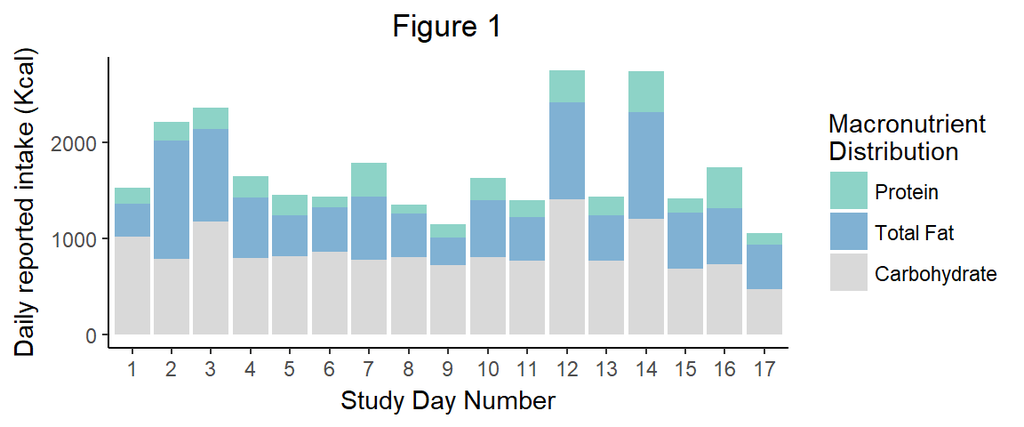

1

This second table shows your average daily intake of key micronutrients from food. Also shown are the average intake levels for all of our study participants and the recommended dietary allowance levels by gender. If you take a vitamin and mineral supplement, your intake from that supplement is not reflected here:

[output not shown]

*Values marked with an asterisk are the recommended dietary allowance or adequate intake values for adults between 18 and 30 years old. These values are the daily intake level that is sufficient to meet the needs of 97-98% of the population. If you are older than 30, your recommended dietary allowance may be higher or lower than what’s shown here. You can visit https://ods.od.nih.gov/Health_Information/Dietary_Reference_Intakes.aspx for a complete list of dietary reference intakes by age and gender.

If your intake of a vitamin or mineral falls below the recommended level for your gender you should consider increasing your intake of foods that are a good source of that vitamin or mineral. For example, the study average intake of vitamin D falls below the recommended level of 15 mcg. So, many of the participants in our study could benefit by eating more vitamin D containing foods like fatty fish (such as salmon, tuna, and mackerel), fortified milk products, beef liver, egg yolks, and mushrooms.

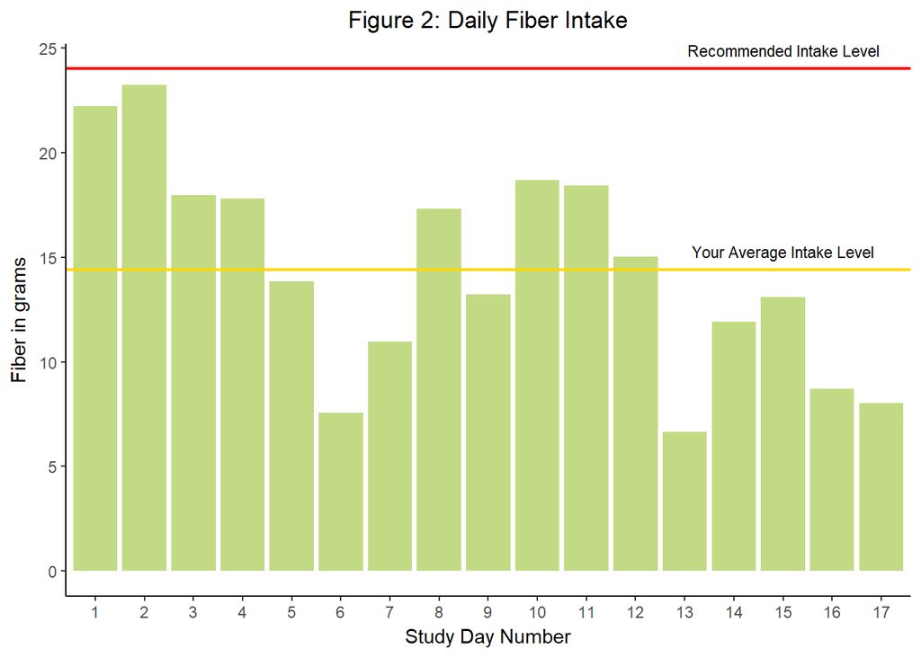

1

# Your Microbiome Composition Data

The next series of plots show information about the composition of your microbiome.

We sequenced the DNA of the microbes that live within your gut from the daily stool samples you provided. We used a type of sequencing called Shallow-shotgun sequencing coupled with programs developed in the Knights’s lab to identify the species of bacteria that live inside you.

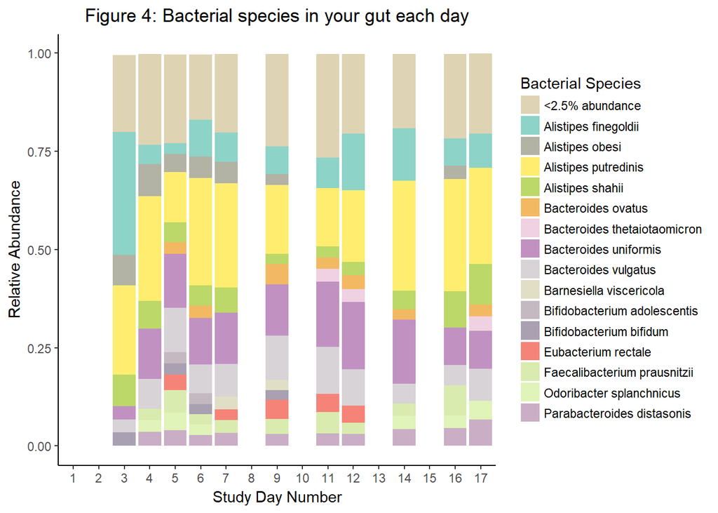

1

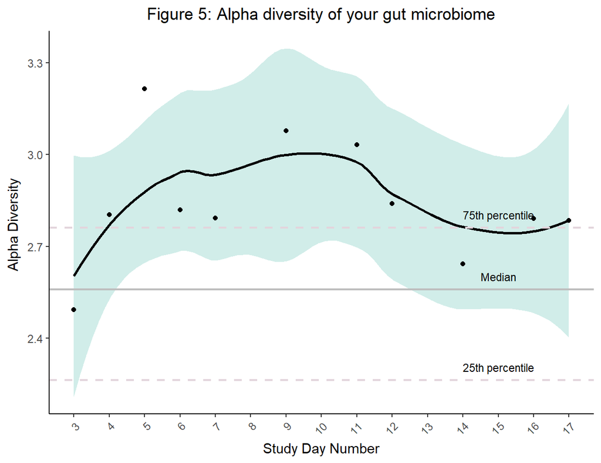

1

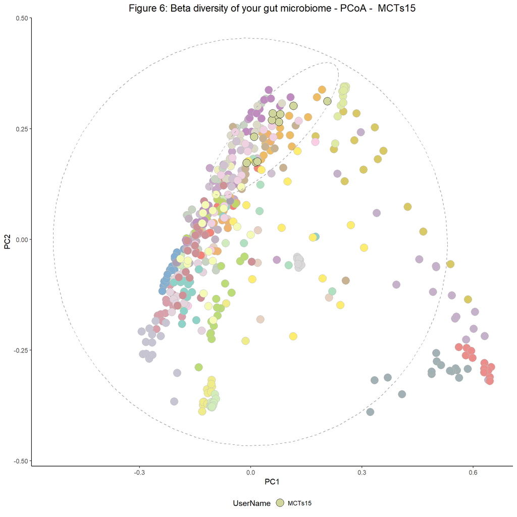

1

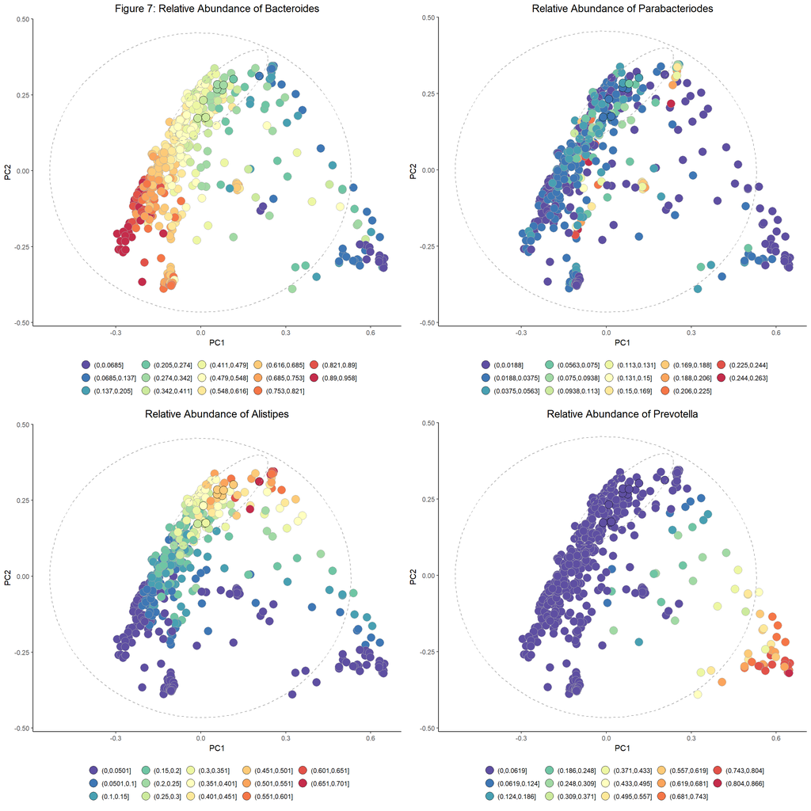

1

# Your blood draw data

The results of your blood draw at the start of the dietary supplementation period are shown in the table below along with the reference ranges. If any of your values fall outside the reference ranges you should contact your health care provider to discuss your results and have the tests rerun.

| Test | Result | Normal Range |
| --- | --- | --- |
| Cholesterol (mg/dL) | 140 | <200 |
| Triglycerides (mg/dL) | 54 | <150 |
| HDL (mg/dL) | 46 | >60 |
| LDL (mg/dL) | 83 | <100 |
| Glucose (mg/dL) | 85 | 70 - 100 |